# Data_Vis

Team OK: Kara Wei, Ouyang Du

2023-10-03

```r
library(mice)
# Specify the file path to your CSV file
file_path <- "/Users/karawei/Desktop/GRAD 3rd/ESE 527/garments_worker_productivity.csv"  # Replace with the actual path to your CSV file

# Use read.csv() to read the CSV file into a data frame
data_prod <- read.csv(file_path)
head(data_prod)
```

```
##       date  quarter department      day team targeted_productivity   smv  wip
## 1 1/1/2015 Quarter1     sweing Thursday    8                  0.80 26.16 1108
## 2 1/1/2015 Quarter1 finishing  Thursday    1                  0.75  3.94   NA
## 3 1/1/2015 Quarter1     sweing Thursday   11                  0.80 11.41  968
## 4 1/1/2015 Quarter1     sweing Thursday   12                  0.80 11.41  968
## 5 1/1/2015 Quarter1     sweing Thursday    6                  0.80 25.90 1170
## 6 1/1/2015 Quarter1     sweing Thursday    7                  0.80 25.90  984
##   over_time incentive idle_time idle_men no_of_style_change no_of_workers
## 1      7080        98         0        0                  0          59.0
## 2       960         0         0        0                  0           8.0
## 3      3660        50         0        0                  0          30.5
## 4      3660        50         0        0                  0          30.5
## 5      1920        50         0        0                  0          56.0
## 6      6720        38         0        0                  0          56.0
##   actual_productivity
## 1           0.9407254
## 2           0.8865000
## 3           0.8005705
## 4           0.8005705
## 5           0.8003819
## 6           0.8001250
```

```r
nrow(data_prod)
```

```
## [1] 1197
```

We first draw out all the histograms for our numerical variables to see the distributions of them.

## Histograms of all numerical variables:

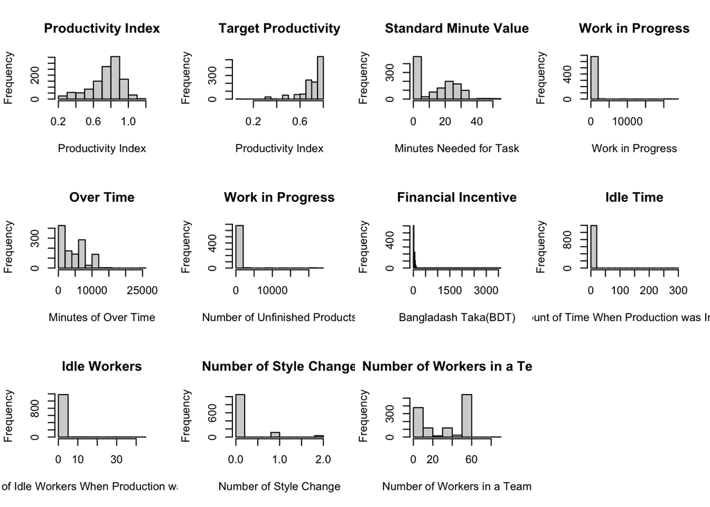

```r
par(mfrow = c(3, 4))
hist(data_prod[["actual_productivity"]],main="Productivity Index",xlab="Productivity Index")
hist(data_prod[["targeted_productivity"]],main="Target Productivity",xlab="Productivity Index")
hist(data_prod[["smv"]],main="Standard Minute Value",xlab="Minutes Needed for Task")
hist(data_prod[["wip"]],main="Work in Progress",xlab="Work in Progress")
hist(data_prod[["over_time"]],main="Over Time",xlab="Minutes of Over Time")
hist(data_prod[["wip"]],main="Work in Progress",xlab="Number of Unfinished Products")
hist(data_prod[["incentive"]],main="Financial Incentive",xlab="Bangladash Taka(BDT)",breaks=200)
hist(data_prod[["idle_time"]],main="Idle Time",xlab="Amount of Time When Production was Interrupted")
hist(data_prod[["idle_men"]],main="Idle Workers",xlab="Number of Idle Workers When Production was Interrupted")
hist(data_prod[["no_of_style_change"]],main="Number of Style Change",xlab="Number of Style Change")
hist(data_prod[["no_of_workers"]],main="Number of Workers in a Team",xlab="Number of Workers in a Team")
```

We notice that wip has many missing (NA) values.

We consider the following ways:

## 1) We try to make remove all rows with missing values.

```r
cleaned_data <- na.omit((data_prod))
head(cleaned_data)
```

```
##       date  quarter department      day team targeted_productivity   smv  wip
## 1 1/1/2015 Quarter1     sweing Thursday    8                  0.80 26.16 1108
## 3 1/1/2015 Quarter1     sweing Thursday   11                  0.80 11.41  968
## 4 1/1/2015 Quarter1     sweing Thursday   12                  0.80 11.41  968
## 5 1/1/2015 Quarter1     sweing Thursday    6                  0.80 25.90 1170
## 6 1/1/2015 Quarter1     sweing Thursday    7                  0.80 25.90  984
## 8 1/1/2015 Quarter1     sweing Thursday    3                  0.75 28.08  795
##   over_time incentive idle_time idle_men no_of_style_change no_of_workers
## 1      7080        98         0        0                  0          59.0
## 3      3660        50         0        0                  0          30.5
## 4      3660        50         0        0                  0          30.5
## 5      1920        50         0        0                  0          56.0
## 6      6720        38         0        0                  0          56.0
## 8      6900        45         0        0                  0          57.5
##   actual_productivity
## 1           0.9407254
## 3           0.8005705
## 4           0.8005705
## 5           0.8003819
## 6           0.8001250
## 8           0.7536835
```

```r
nrow(cleaned_data)
```

```
## [1] 691
```

As shown above, this costs a size reduction from 1197 rows to 691 rows.

## 2) Replace all NA values to 0s.

```r
data_replaced_by_zero <- data_prod
data_replaced_by_zero$wip <- replace(data_replaced_by_zero$wip,is.na(data_replaced_by_zero$wip),0)
head(data_replaced_by_zero)
```

```
##       date  quarter department      day team targeted_productivity   smv  wip
## 1 1/1/2015 Quarter1     sweing Thursday    8                  0.80 26.16 1108
## 2 1/1/2015 Quarter1 finishing  Thursday    1                  0.75  3.94    0
## 3 1/1/2015 Quarter1     sweing Thursday   11                  0.80 11.41  968
## 4 1/1/2015 Quarter1     sweing Thursday   12                  0.80 11.41  968
## 5 1/1/2015 Quarter1     sweing Thursday    6                  0.80 25.90 1170
## 6 1/1/2015 Quarter1     sweing Thursday    7                  0.80 25.90  984
##   over_time incentive idle_time idle_men no_of_style_change no_of_workers
## 1      7080        98         0        0                  0          59.0
## 2       960         0         0        0                  0           8.0
## 3      3660        50         0        0                  0          30.5
## 4      3660        50         0        0                  0          30.5
## 5      1920        50         0        0                  0          56.0
## 6      6720        38         0        0                  0          56.0
##   actual_productivity
## 1           0.9407254
## 2           0.8865000
## 3           0.8005705
## 4           0.8005705
## 5           0.8003819
## 6           0.8001250
```

Now our data set looks complete. The only concern is that given wip values seem to be far away from 0. Adding such 0 might cause outliers and biased data.

```r
data_replaced_by_mean <- data_prod
data_replaced_by_mean$wip <- replace(data_replaced_by_mean$wip,is.na(data_replaced_by_mean$wip),mean(data_replaced_by_mean$wip,na.rm = TRUE))
head(data_replaced_by_mean)
```

```
##       date  quarter department      day team targeted_productivity   smv
## 1 1/1/2015 Quarter1     sweing Thursday    8                  0.80 26.16
## 2 1/1/2015 Quarter1 finishing  Thursday    1                  0.75  3.94
## 3 1/1/2015 Quarter1     sweing Thursday   11                  0.80 11.41
## 4 1/1/2015 Quarter1     sweing Thursday   12                  0.80 11.41
## 5 1/1/2015 Quarter1     sweing Thursday    6                  0.80 25.90
## 6 1/1/2015 Quarter1     sweing Thursday    7                  0.80 25.90
##        wip over_time incentive idle_time idle_men no_of_style_change
## 1 1108.000      7080        98         0        0                  0
## 2 1190.466       960         0         0        0                  0
## 3  968.000      3660        50         0        0                  0
## 4  968.000      3660        50         0        0                  0
## 5 1170.000      1920        50         0        0                  0
## 6  984.000      6720        38         0        0                  0
##   no_of_workers actual_productivity
## 1          59.0           0.9407254
## 2           8.0           0.8865000
## 3          30.5           0.8005705
## 4          30.5           0.8005705
## 5          56.0           0.8003819
## 6          56.0           0.8001250
```

```r
cat("The mean of wip after removing all NA value rows is", mean(data_replaced_by_mean$wip,na.rm = TRUE))
```

```
## The mean of wip after removing all NA value rows is 1190.466
```

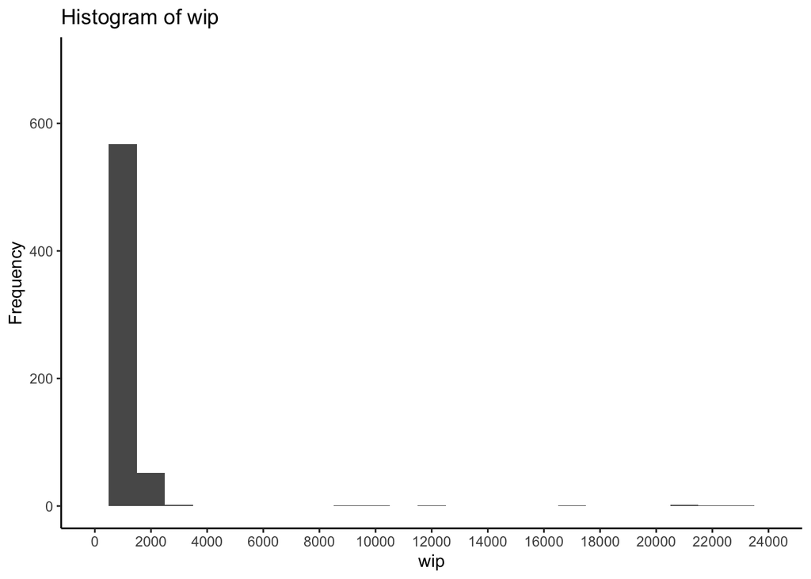

```r
ggplot(data = data_prod, aes(x = wip)) +
  geom_histogram(binwidth = 1000) +
  scale_x_continuous(limits = c(0, 24000), breaks = seq(0, 24000, by = 2000))+
  scale_y_continuous(limits = c(0, 700))+
  labs(title = "Histogram of wip",
       x = "wip",
       y = "Frequency") +
  theme_classic()
```

As we can see, most of the values are concentrated within the wip range from 0 to 2000. Our mean is 1190.466, which means our mean and mode are quite close. Our idea of replacing with mean makes sense. However, just to be more accurate, we preform the same idea with median replacement and make sure they are all consistent.

## 4) Replacing the values using median

```r
data_replaced_by_median <- data_prod
data_replaced_by_median$wip <- replace(data_replaced_by_median$wip,is.na(data_replaced_by_median$wip),median(data_replaced_by_median$wip,na.rm = TRUE))
head(data_replaced_by_median)
```

```
##       date  quarter department      day team targeted_productivity   smv  wip
## 1 1/1/2015 Quarter1     sweing Thursday    8                  0.80 26.16 1108
## 2 1/1/2015 Quarter1 finishing  Thursday    1                  0.75  3.94 1039
## 3 1/1/2015 Quarter1     sweing Thursday   11                  0.80 11.41  968
## 4 1/1/2015 Quarter1     sweing Thursday   12                  0.80 11.41  968
## 5 1/1/2015 Quarter1     sweing Thursday    6                  0.80 25.90 1170
## 6 1/1/2015 Quarter1     sweing Thursday    7                  0.80 25.90  984
##   over_time incentive idle_time idle_men no_of_style_change no_of_workers
## 1      7080        98         0        0                  0          59.0
## 2       960         0         0        0                  0           8.0
## 3      3660        50         0        0                  0          30.5
## 4      3660        50         0        0                  0          30.5
## 5      1920        50         0        0                  0          56.0
## 6      6720        38         0        0                  0          56.0
##   actual_productivity
## 1           0.9407254
## 2           0.8865000
## 3           0.8005705
## 4           0.8005705
## 5           0.8003819
## 6           0.8001250
```

```r
cat("The median of wip after removing all NA value rows is", median(data_replaced_by_median$wip,na.rm = TRUE))
```

```
## The median of wip after removing all NA value rows is 1039
```

The median is 1039, which is quite close to the mean.

5. Using Multivariate Imputation by Chained Equations (MICE): regress the missing variable as predictive from other variables.

```r
data_replaced_by_mice <- mice(data_prod,m=5,maxit=50,meth='pmm',seed=500)
#summary(data_replaced_by_mice)
```

```r
completeData <- complete(data_replaced_by_mice,2)
head(completeData)
```

```
##       date  quarter department      day team targeted_productivity   smv  wip
## 1 1/1/2015 Quarter1     sweing Thursday    8                  0.80 26.16 1108
## 2 1/1/2015 Quarter1 finishing  Thursday    1                  0.75  3.94  934
## 3 1/1/2015 Quarter1     sweing Thursday   11                  0.80 11.41  968
## 4 1/1/2015 Quarter1     sweing Thursday   12                  0.80 11.41  968
## 5 1/1/2015 Quarter1     sweing Thursday    6                  0.80 25.90 1170
## 6 1/1/2015 Quarter1     sweing Thursday    7                  0.80 25.90  984
##   over_time incentive idle_time idle_men no_of_style_change no_of_workers
## 1      7080        98         0        0                  0          59.0
## 2       960         0         0        0                  0           8.0
## 3      3660        50         0        0                  0          30.5
## 4      3660        50         0        0                  0          30.5
## 5      1920        50         0        0                  0          56.0
## 6      6720        38         0        0                  0          56.0
##   actual_productivity
## 1           0.9407254
## 2           0.8865000
## 3           0.8005705
## 4           0.8005705
## 5           0.8003819
## 6           0.8001250
```

The concern is that we have high portion of wip values depending on other variables (since we regresse wip on other variables.).

```r
# library(GGally)
# ggpairs(data_prod,columns = 9:15)
```

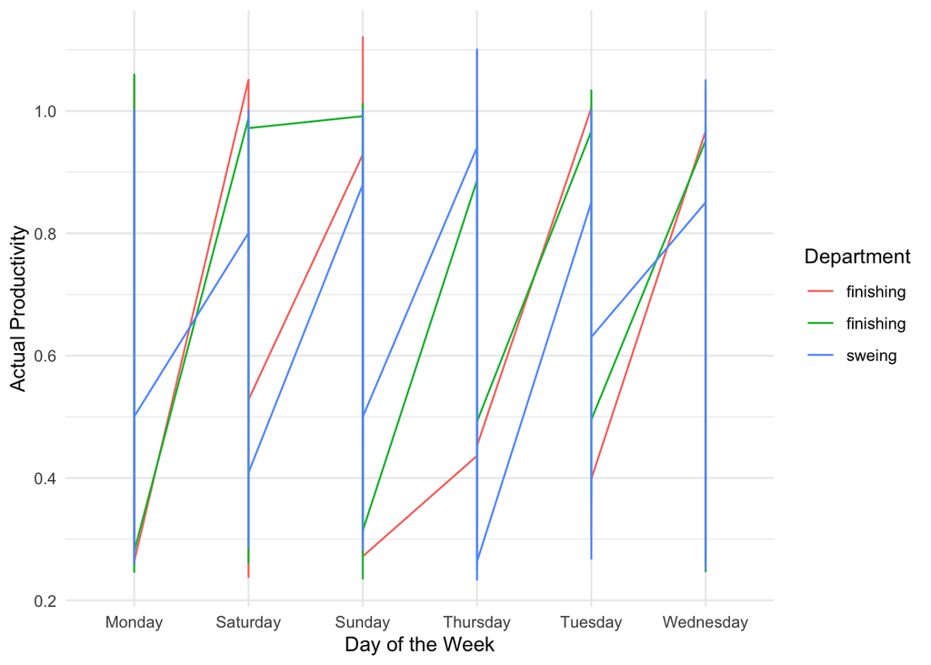

```r
ggplot(data_prod) +
  geom_line(aes(x = day, y = actual_productivity,color=department, group=department)) +
  #scale_y_continuous(limits = c(0.2, 1), breaks = seq(0, 1, by = 0.1))+
  labs(x="Day of the Week", y = "Actual Productivity", color = "Department") +
  theme_minimal()
```

## References:

https://www.r-bloggers.com/2022/03/imputing-missing-values-in-r/ https://www.analyticsvidhya.com/blog/2016/03/tutorial-powerful-packages-imputing-missing-values/ https://cran.r-project.org/web/packages/mice/readme/README.html